# Prosper Loan Dataset Exploration

### by Okebiorun Sarah

#### Preliminary Wrangling

##### Introduction

This is a datset of Proser Loans that contains 113937 loans with 81 variables on each loan, including loan amount, borrower rate, current loan status, borrower income, and many others. We will use Python data science and data visualization libraries to explore the dataset’s variables and understand the data’s structure, patterns and relationships. We will also take our main findings from our exploration and convey them to others through an explanatory analysis.

```python
import numpy as np
import pandas as pd
import matplotlib.pyplot as plt
import seaborn as sns


%matplotlib inline
```

```python
# read our csv
loan = pd.read_csv('prosperLoanData.csv')
```

```python
loan.head()
```

|  | ListingKey | ListingNumber | ListingCreationDate | CreditGrade | Term | LoanStatus | ClosedDate | BorrowerAPR | BorrowerRate | LenderYield | ... | LP_ServiceFees | LP_CollectionFees | LP_GrossPrincipalLoss | LP_NetPrincipalLoss | LP_NonPrincipalRecoverypayments | PercentFunded | Recommendations | InvestmentFromFriendsCount | InvestmentFromFriendsAmount | Investors |
| --- | --- | --- | --- | --- | --- | --- | --- | --- | --- | --- | --- | --- | --- | --- | --- | --- | --- | --- | --- | --- | --- |
| 0 | 1021339766868145413AB3B | 193129 | 2007-08-26 19:09:29.263000000 | C | 36 | Completed | 2009-08-14 00:00:00 | 0.16516 | 0.1580 | 0.1380 | ... | -133.18 | 0.0 | 0.0 | 0.0 | 0.0 | 1.0 | 0 | 0 | 0.0 | 258 |
| 1 | 10273602499503308B223C1 | 1209647 | 2014-02-27 08:28:07.900000000 | NaN | 36 | Current | NaN | 0.12016 | 0.0920 | 0.0820 | ... | 0.00 | 0.0 | 0.0 | 0.0 | 0.0 | 1.0 | 0 | 0 | 0.0 | 1 |
| 2 | 0EE9337825851032864889A | 81716 | 2007-01-05 15:00:47.090000000 | HR | 36 | Completed | 2009-12-17 00:00:00 | 0.28269 | 0.2750 | 0.2400 | ... | -24.20 | 0.0 | 0.0 | 0.0 | 0.0 | 1.0 | 0 | 0 | 0.0 | 41 |
| 3 | 0EF5356002482715299901A | 658116 | 2012-10-22 11:02:35.010000000 | NaN | 36 | Current | NaN | 0.12528 | 0.0974 | 0.0874 | ... | -108.01 | 0.0 | 0.0 | 0.0 | 0.0 | 1.0 | 0 | 0 | 0.0 | 158 |
| 4 | 0F023589499656230C5E3E2 | 909464 | 2013-09-14 18:38:39.097000000 | NaN | 36 | Current | NaN | 0.24614 | 0.2085 | 0.1985 | ... | -60.27 | 0.0 | 0.0 | 0.0 | 0.0 | 1.0 | 0 | 0 | 0.0 | 20 |

5 rows × 81 columns

```python
loan.info()
```

```
<class 'pandas.core.frame.DataFrame'>
RangeIndex: 113937 entries, 0 to 113936
Data columns (total 81 columns):
 #   Column                               Non-Null Count   Dtype
---  ------                               --------------   -----
 0   ListingKey                           113937 non-null  object
 1   ListingNumber                        113937 non-null  int64
 2   ListingCreationDate                  113937 non-null  object
 3   CreditGrade                          28953 non-null   object
 4   Term                                 113937 non-null  int64
 5   LoanStatus                           113937 non-null  object
 6   ClosedDate                           55089 non-null   object
 7   BorrowerAPR                          113912 non-null  float64
 8   BorrowerRate                         113937 non-null  float64
 9   LenderYield                          113937 non-null  float64
```

[output cut: 73 more lines]

```python
loan.describe()
```

|  | ListingNumber | Term | BorrowerAPR | BorrowerRate | LenderYield | EstimatedEffectiveYield | EstimatedLoss | EstimatedReturn | ProsperRating (numeric) | ProsperScore | ... | LP_ServiceFees | LP_CollectionFees | LP_GrossPrincipalLoss | LP_NetPrincipalLoss | LP_NonPrincipalRecoverypayments | PercentFunded | Recommendations | InvestmentFromFriendsCount | InvestmentFromFriendsAmount | Investors |
| --- | --- | --- | --- | --- | --- | --- | --- | --- | --- | --- | --- | --- | --- | --- | --- | --- | --- | --- | --- | --- | --- |
| count | 1.139370e+05 | 113937.000000 | 113912.000000 | 113937.000000 | 113937.000000 | 84853.000000 | 84853.000000 | 84853.000000 | 84853.000000 | 84853.000000 | ... | 113937.000000 | 113937.000000 | 113937.000000 | 113937.000000 | 113937.000000 | 113937.000000 | 113937.000000 | 113937.000000 | 113937.000000 | 113937.000000 |
| mean | 6.278857e+05 | 40.830248 | 0.218828 | 0.192764 | 0.182701 | 0.168661 | 0.080306 | 0.096068 | 4.072243 | 5.950067 | ... | -54.725641 | -14.242698 | 700.446342 | 681.420499 | 25.142686 | 0.998584 | 0.048027 | 0.023460 | 16.550751 | 80.475228 |
| std | 3.280762e+05 | 10.436212 | 0.080364 | 0.074818 | 0.074516 | 0.068467 | 0.046764 | 0.030403 | 1.673227 | 2.376501 | ... | 60.675425 | 109.232758 | 2388.513831 | 2357.167068 | 275.657937 | 0.017919 | 0.332353 | 0.232412 | 294.545422 | 103.239020 |
| min | 4.000000e+00 | 12.000000 | 0.006530 | 0.000000 | -0.010000 | -0.182700 | 0.004900 | -0.182700 | 1.000000 | 1.000000 | ... | -664.870000 | -9274.750000 | -94.200000 | -954.550000 | 0.000000 | 0.700000 | 0.000000 | 0.000000 | 0.000000 | 1.000000 |
| 25% | 4.009190e+05 | 36.000000 | 0.156290 | 0.134000 | 0.124200 | 0.115670 | 0.042400 | 0.074080 | 3.000000 | 4.000000 | ... | -73.180000 | 0.000000 | 0.000000 | 0.000000 | 0.000000 | 1.000000 | 0.000000 | 0.000000 | 0.000000 | 2.000000 |
| 50% | 6.005540e+05 | 36.000000 | 0.209760 | 0.184000 | 0.173000 | 0.161500 | 0.072400 | 0.091700 | 4.000000 | 6.000000 | ... | -34.440000 | 0.000000 | 0.000000 | 0.000000 | 0.000000 | 1.000000 | 0.000000 | 0.000000 | 0.000000 | 44.000000 |
| 75% | 8.926340e+05 | 36.000000 | 0.283810 | 0.250000 | 0.240000 | 0.224300 | 0.112000 | 0.116600 | 5.000000 | 8.000000 | ... | -13.920000 | 0.000000 | 0.000000 | 0.000000 | 0.000000 | 1.000000 | 0.000000 | 0.000000 | 0.000000 | 115.000000 |
| max | 1.255725e+06 | 60.000000 | 0.512290 | 0.497500 | 0.492500 | 0.319900 | 0.366000 | 0.283700 | 7.000000 | 11.000000 | ... | 32.060000 | 0.000000 | 25000.000000 | 25000.000000 | 21117.900000 | 1.012500 | 39.000000 | 33.000000 | 25000.000000 | 1189.000000 |

8 rows × 61 columns

```python
loan=loan.drop_duplicates()
```

```python
loan.info()
```

```
<class 'pandas.core.frame.DataFrame'>
Int64Index: 113937 entries, 0 to 113936
Data columns (total 81 columns):
 #   Column                               Non-Null Count   Dtype
---  ------                               --------------   -----
 0   ListingKey                           113937 non-null  object
 1   ListingNumber                        113937 non-null  int64
 2   ListingCreationDate                  113937 non-null  object
 3   CreditGrade                          28953 non-null   object
 4   Term                                 113937 non-null  int64
 5   LoanStatus                           113937 non-null  object
 6   ClosedDate                           55089 non-null   object
 7   BorrowerAPR                          113912 non-null  float64
 8   BorrowerRate                         113937 non-null  float64
 9   LenderYield                          113937 non-null  float64
```

[output cut: 73 more lines]

```python
loan.dropna()
```

|  | ListingKey | ListingNumber | ListingCreationDate | CreditGrade | Term | LoanStatus | ClosedDate | BorrowerAPR | BorrowerRate | LenderYield | ... | LP_ServiceFees | LP_CollectionFees | LP_GrossPrincipalLoss | LP_NetPrincipalLoss | LP_NonPrincipalRecoverypayments | PercentFunded | Recommendations | InvestmentFromFriendsCount | InvestmentFromFriendsAmount | Investors |
| --- | --- | --- | --- | --- | --- | --- | --- | --- | --- | --- | --- | --- | --- | --- | --- | --- | --- | --- | --- | --- | --- |

0 rows × 81 columns

```python
loan.isnull()
```

|  | ListingKey | ListingNumber | ListingCreationDate | CreditGrade | Term | LoanStatus | ClosedDate | BorrowerAPR | BorrowerRate | LenderYield | ... | LP_ServiceFees | LP_CollectionFees | LP_GrossPrincipalLoss | LP_NetPrincipalLoss | LP_NonPrincipalRecoverypayments | PercentFunded | Recommendations | InvestmentFromFriendsCount | InvestmentFromFriendsAmount | Investors |
| --- | --- | --- | --- | --- | --- | --- | --- | --- | --- | --- | --- | --- | --- | --- | --- | --- | --- | --- | --- | --- | --- |
| 0 | False | False | False | False | False | False | False | False | False | False | ... | False | False | False | False | False | False | False | False | False | False |
| 1 | False | False | False | True | False | False | True | False | False | False | ... | False | False | False | False | False | False | False | False | False | False |
| 2 | False | False | False | False | False | False | False | False | False | False | ... | False | False | False | False | False | False | False | False | False | False |
| 3 | False | False | False | True | False | False | True | False | False | False | ... | False | False | False | False | False | False | False | False | False | False |
| 4 | False | False | False | True | False | False | True | False | False | False | ... | False | False | False | False | False | False | False | False | False | False |
| ... | ... | ... | ... | ... | ... | ... | ... | ... | ... | ... | ... | ... | ... | ... | ... | ... | ... | ... | ... | ... | ... |
| 113932 | False | False | False | True | False | False | True | False | False | False | ... | False | False | False | False | False | False | False | False | False | False |
| 113933 | False | False | False | True | False | False | True | False | False | False | ... | False | False | False | False | False | False | False | False | False | False |
| 113934 | False | False | False | True | False | False | True | False | False | False | ... | False | False | False | False | False | False | False | False | False | False |
| 113935 | False | False | False | True | False | False | False | False | False | False | ... | False | False | False | False | False | False | False | False | False | False |
| 113936 | False | False | False | True | False | False | True | False | False | False | ... | False | False | False | False | False | False | False | False | False | False |

113937 rows × 81 columns

```python
loan.fillna(value= 'unknown')
```

|  | ListingKey | ListingNumber | ListingCreationDate | CreditGrade | Term | LoanStatus | ClosedDate | BorrowerAPR | BorrowerRate | LenderYield | ... | LP_ServiceFees | LP_CollectionFees | LP_GrossPrincipalLoss | LP_NetPrincipalLoss | LP_NonPrincipalRecoverypayments | PercentFunded | Recommendations | InvestmentFromFriendsCount | InvestmentFromFriendsAmount | Investors |
| --- | --- | --- | --- | --- | --- | --- | --- | --- | --- | --- | --- | --- | --- | --- | --- | --- | --- | --- | --- | --- | --- |
| 0 | 1021339766868145413AB3B | 193129 | 2007-08-26 19:09:29.263000000 | C | 36 | Completed | 2009-08-14 00:00:00 | 0.16516 | 0.1580 | 0.1380 | ... | -133.18 | 0.0 | 0.0 | 0.0 | 0.0 | 1.0 | 0 | 0 | 0.0 | 258 |
| 1 | 10273602499503308B223C1 | 1209647 | 2014-02-27 08:28:07.900000000 | unknown | 36 | Current | unknown | 0.12016 | 0.0920 | 0.0820 | ... | 0.00 | 0.0 | 0.0 | 0.0 | 0.0 | 1.0 | 0 | 0 | 0.0 | 1 |
| 2 | 0EE9337825851032864889A | 81716 | 2007-01-05 15:00:47.090000000 | HR | 36 | Completed | 2009-12-17 00:00:00 | 0.28269 | 0.2750 | 0.2400 | ... | -24.20 | 0.0 | 0.0 | 0.0 | 0.0 | 1.0 | 0 | 0 | 0.0 | 41 |
| 3 | 0EF5356002482715299901A | 658116 | 2012-10-22 11:02:35.010000000 | unknown | 36 | Current | unknown | 0.12528 | 0.0974 | 0.0874 | ... | -108.01 | 0.0 | 0.0 | 0.0 | 0.0 | 1.0 | 0 | 0 | 0.0 | 158 |
| 4 | 0F023589499656230C5E3E2 | 909464 | 2013-09-14 18:38:39.097000000 | unknown | 36 | Current | unknown | 0.24614 | 0.2085 | 0.1985 | ... | -60.27 | 0.0 | 0.0 | 0.0 | 0.0 | 1.0 | 0 | 0 | 0.0 | 20 |
| ... | ... | ... | ... | ... | ... | ... | ... | ... | ... | ... | ... | ... | ... | ... | ... | ... | ... | ... | ... | ... | ... |
| 113932 | E6D9357655724827169606C | 753087 | 2013-04-14 05:55:02.663000000 | unknown | 36 | Current | unknown | 0.22354 | 0.1864 | 0.1764 | ... | -75.58 | 0.0 | 0.0 | 0.0 | 0.0 | 1.0 | 0 | 0 | 0.0 | 1 |
| 113933 | E6DB353036033497292EE43 | 537216 | 2011-11-03 20:42:55.333000000 | unknown | 36 | FinalPaymentInProgress | unknown | 0.1322 | 0.1110 | 0.1010 | ... | -30.05 | 0.0 | 0.0 | 0.0 | 0.0 | 1.0 | 0 | 0 | 0.0 | 22 |
| 113934 | E6E13596170052029692BB1 | 1069178 | 2013-12-13 05:49:12.703000000 | unknown | 60 | Current | unknown | 0.23984 | 0.2150 | 0.2050 | ... | -16.91 | 0.0 | 0.0 | 0.0 | 0.0 | 1.0 | 0 | 0 | 0.0 | 119 |
| 113935 | E6EB3531504622671970D9E | 539056 | 2011-11-14 13:18:26.597000000 | unknown | 60 | Completed | 2013-08-13 00:00:00 | 0.28408 | 0.2605 | 0.2505 | ... | -235.05 | 0.0 | 0.0 | 0.0 | 0.0 | 1.0 | 0 | 0 | 0.0 | 274 |
| 113936 | E6ED3600409833199F711B7 | 1140093 | 2014-01-15 09:27:37.657000000 | unknown | 36 | Current | unknown | 0.13189 | 0.1039 | 0.0939 | ... | -1.70 | 0.0 | 0.0 | 0.0 | 0.0 | 1.0 | 0 | 0 | 0.0 | 1 |

113937 rows × 81 columns

For our analysis, I'll check if borrower is concerned about the APR, he/she will be charged for the loan.

# Univariate Analysis

In this analysis,We'll be answering the following question

1. What the Borrower’s interest rate for prosper loan
2. The Borrower’s APR for prosper loan. Every borrower is concerned about the APR, he/she will be charged for the loan.
3. And lastly,does the borrower owns house at the time of listing (True & False)

Now let's our analysis answer the question.

```python
#creating a new dataframe
df = loan.copy()
```

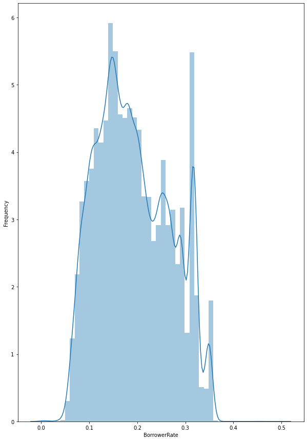

```python
# borrower rate
def lables_name(x , y = None):
    plt.xlabel(x)
    plt.ylabel(y)
    """ Quick hack for creating displots with seaborn """
    default_color = sns.color_palette()[0]


plt.figure(figsize = [10,15])
sns.distplot(df['BorrowerRate']);
lables_name('BorrowerRate')
plt.ylabel('Frequency')
```

```python
df['BorrowerRate'].describe()
```

```
count    113937.000000
mean          0.192764
std           0.074818
min           0.000000
25%           0.134000
50%           0.184000
75%           0.250000
max           0.497500
Name: BorrowerRate, dtype: float64
```

From the above analysis,we can detect that the distribution isn't normal. But, what we can bring out from this is that our mean is 0.19 and the maximum borrowed rate is 0.49 and the minimum is 0.0. And the standard deviation for this analysis is 0.07.

Now, let's look for the analysis for the burrower APR.

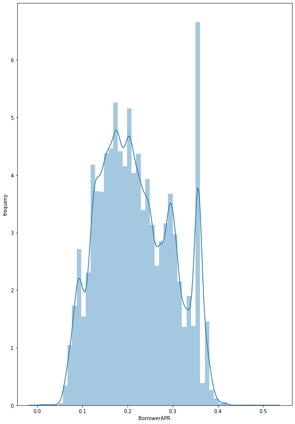

```python
plt.figure(figsize = [10,15])
sns.distplot(df['BorrowerAPR']);
lables_name('BorrowerAPR')
plt.ylabel('frequeny')
```

```python
df['BorrowerAPR'].describe()
```

```
count    113912.000000
mean          0.218828
std           0.080364
min           0.006530
25%           0.156290
50%           0.209760
75%           0.283810
max           0.512290
Name: BorrowerAPR, dtype: float64
```

From the above analysis,every borrower is concerned about the APR, he/she will be charged for the loan, so now from the analysis we can see that the average a person would be chargered for a loan is 0.2, the maximum would be 0.51 and the minimum would be 0.00. So, the mean of this analysis is 0.21 and the standard deviation of this analysis is 0.08.

Now, a question came to mind,and the question is, how many of this borrower are home owners? Let's use analysis to answer that.

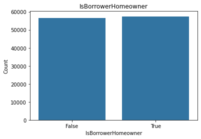

```python
base_color = sns.color_palette()[0]
sns.countplot(data = df , x='IsBorrowerHomeowner' , color =base_color)
plt.title('IsBorrowerHomeowner');
plt.xlabel('IsBorrowerHomeowner');
plt.ylabel('Count');
```

```python
df['IsBorrowerHomeowner'].describe()
```

```
count     113937
unique         2
top         True
freq       57478
Name: IsBorrowerHomeowner, dtype: object
```

So,now has this analysis answwered your question? From this analysis we can see that it's balanced, which implies that borrowers that have their own home are half and burrowers that does't have their own home are half.

# Bivariate Exploration

In this analysis, we would be finding the relationship between two entities,but,what question would be considered. Let's consider the following question

Now let's consider those questions

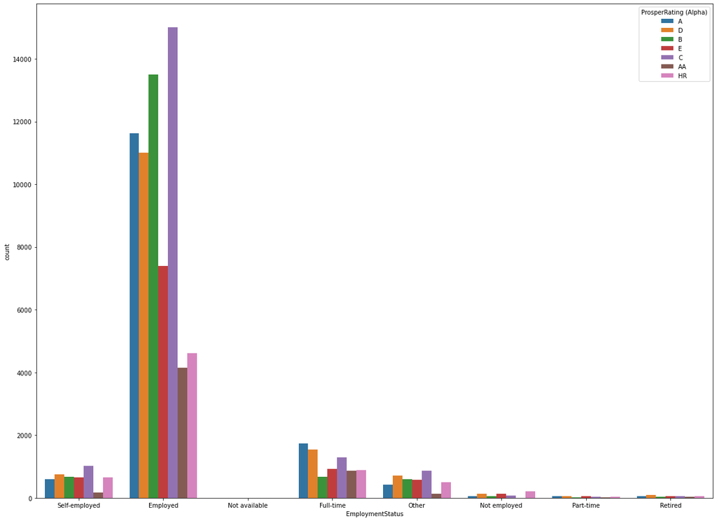

```python
#Relationships between EmploymentStatust vs ProsperRating (Alpha)
plt.figure(figsize = [20,15])
sns.countplot(x= 'EmploymentStatus', hue = 'ProsperRating (Alpha)',data = df)
plt.show;
```

```python
df['EmploymentStatus'].describe()
```

```
count       111682
unique           8
top       Employed
freq         67322
Name: EmploymentStatus, dtype: object
```

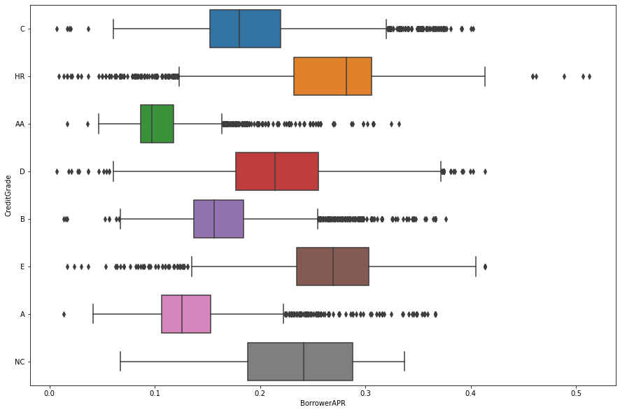

```python
#Relationships between CreditGrade vs BorrowerRate
plt.figure(figsize = [15,10])
sns.boxplot(y = 'CreditGrade', x= 'BorrowerAPR',data = df)

plt.show;
```

[output not shown]

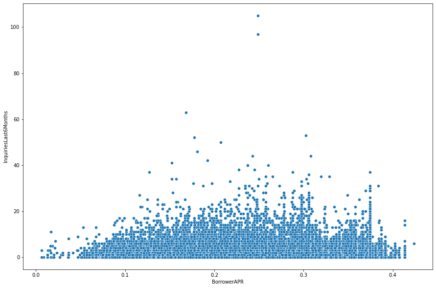

```python
#Relationships between InquiriesLast6Months vs BorrowerRate
plt.figure(figsize = [15,10])
sns.scatterplot(y = 'InquiriesLast6Months', x= 'BorrowerAPR',data = df)
plt.ylabel('InquiriesLast6Months')
plt.show
```

```python
df['InquiriesLast6Months'].describe()
```

```
count    113240.000000
mean          1.435085
std           2.437507
min           0.000000
25%           0.000000
50%           1.000000
75%           2.000000
max         105.000000
Name: InquiriesLast6Months, dtype: float64
```

From the above scatter plot analysis we can see that within the last 6 month, we noticed that the borrowers who make more frequent inquiries would we charged higher APR, but we really don't have much difference.

[output not shown]

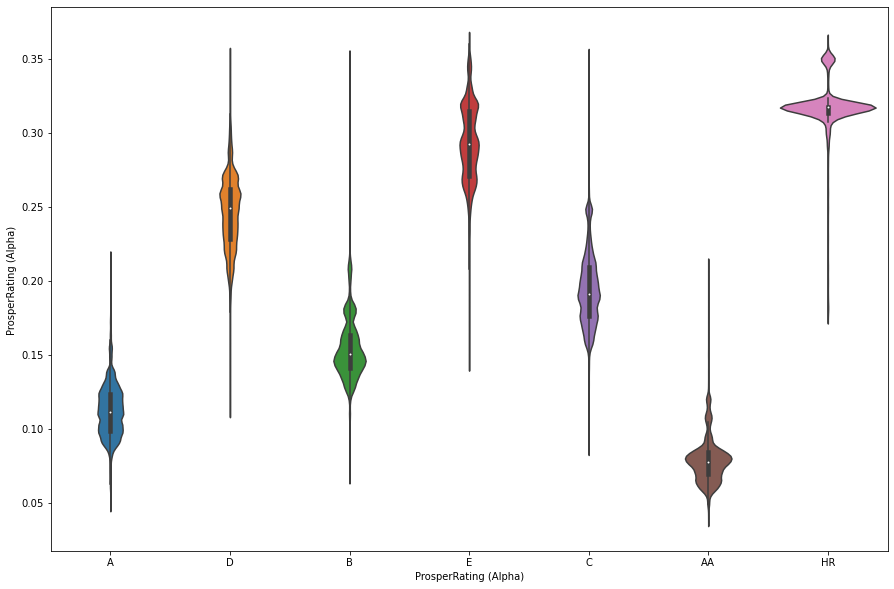

```python
#Relationships between ProsperRating (Alpha) vs BorrowerRate
plt.figure(figsize = [15,10])
sns.violinplot(y = 'BorrowerRate', x= 'ProsperRating (Alpha)',data = df)
plt.ylabel('ProsperRating (Alpha) ')
plt.show
```

[output not shown]

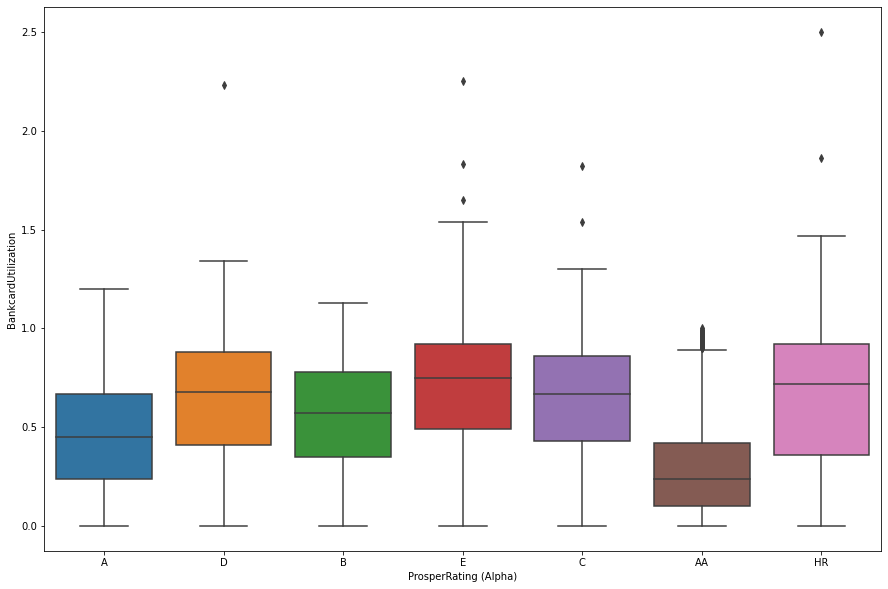

```python
#Relationships between ProsperRating (Alpha) vs BankcardUtilization
plt.figure(figsize = [15,10])
sns.boxplot(y = 'BankcardUtilization', x= 'ProsperRating (Alpha)',data = df)
plt.ylabel('BankcardUtilization')
plt.show
```

# Multivariate Exploration

In this analysis, we are going to be considering the following question

Let consider this

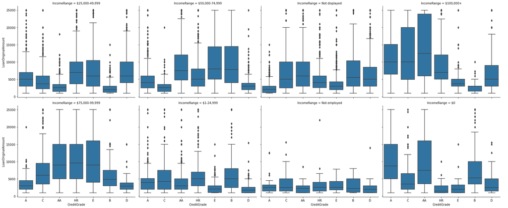

```python
#LoanOriginalAmount,IncomeRange and CreditGrade relationship
def boxgrid(x, y, **kwargs):
    """ Quick hack for creating box plots with seaborn """
    default_color = sns.color_palette()[0]
    sns.boxplot(x, y, color = default_color)
g=sns.FacetGrid(data= df, aspect=1.2, height=5, col='IncomeRange', col_wrap=4)
g.map(sns.boxplot, 'CreditGrade', 'LoanOriginalAmount');
g.add_legend()
```

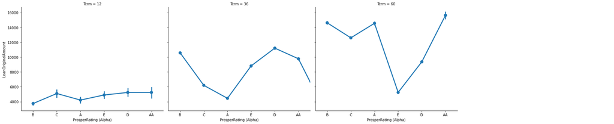

```python
g=sns.FacetGrid(data= df, aspect=1.2, height=5, col='Term', col_wrap=4)
g.map(sns.pointplot, 'ProsperRating (Alpha)', 'LoanOriginalAmount');
g.add_legend()
```

```python
# save the cleaned dataset for explanatory data analysis
df.to_csv('LoanData_explore.csv')
```

# Conclustion

I got great practice in analysing a dataset, using seaborn for visualisations. I'm sure that with some more time, and, of course, some more learning, I could do better. But the purpose of this notebook was to sharpen my skills. So,far there's been a lot of struggles,but with the help of my course at udacity and futher research i was able to show some visualization.